# p8105_hw5_zz3460

Zihan Zhou

2025-11-05

## Problem 1

Load necessary packages and set seed.

```r
set.seed(2025)
library(tidyverse)
```

```r
library(ggplot2)
```

Define a function to solve the problem.

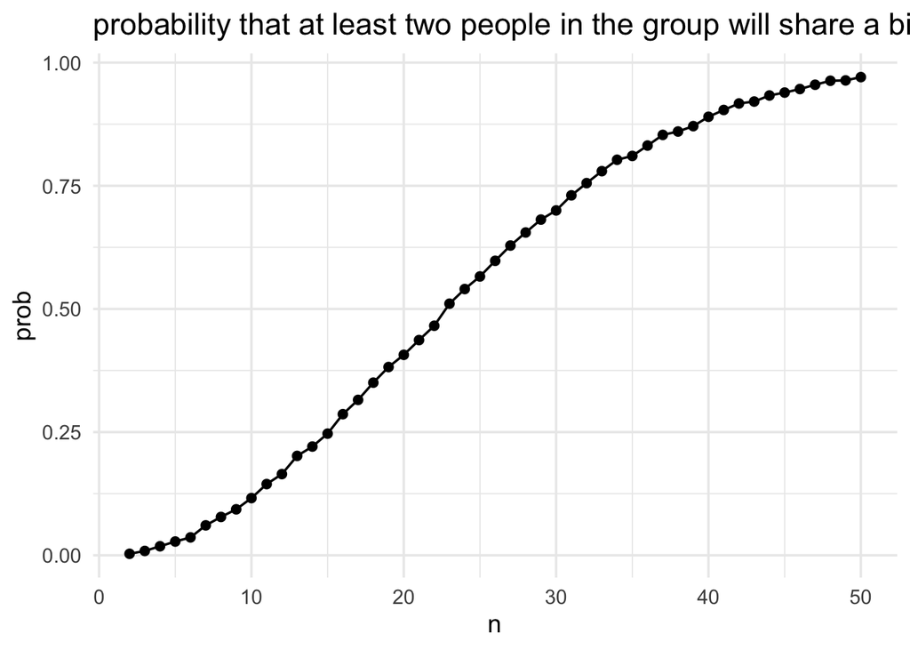

```r
has_shared_birthday <- function(n){
  bdays <- sample(1:365, size = n, replace = TRUE)
  any(duplicated(bdays))
}

reps <- 10000
ns <- 2:50

results <- tibble(
  n = ns,
  prob = map_dbl(ns, ~ mean(replicate(reps, has_shared_birthday(.x))))
)

ggplot(results, aes(x = n, y = prob)) +
  geom_line() +
  geom_point() +
  labs(
    title = "probability that at least two people in the group will share a birthday",
    x = "n",
    y = "prob"
  ) +
  theme_minimal(base_size = 14)
```

The plot shows that: 1. When the group size is over 23, the probability is above 50%. 2. When the group size reaches 50, the probability is close to 100%.

## Problem 2

Load key packages.

```r
library(broom)
library(purrr)
```

Do simulations.

```r
n <- 30
sigma <- 5
mus <- 0:6
reps <- 5000

simulate_for_mu <- function(mu){
  replicate(reps, {
    x <- rnorm(n, mean = mu, sd = sigma)
    t_out <- t.test(x, mu = 0)
    tidy(t_out)[c("estimate", "p.value")]
  }, simplify = FALSE) %>%
  bind_rows(.id = "sim") %>%
  mutate(mu = mu)
}

sim_all <- map_dfr(mus, simulate_for_mu)

power_by_mu <- sim_all %>%
  mutate(reject = p.value < 0.05) %>%
  group_by(mu) %>%
  summarise(power = mean(reject),
  mean_est = mean(estimate),
  mean_est_reject = mean(estimate[reject], na.rm = TRUE),
  n_reject = sum(reject))

power_by_mu
```

```
## # A tibble: 7 × 5
##      mu  power mean_est mean_est_reject n_reject
##   <int>  <dbl>    <dbl>           <dbl>    <int>
## 1     0 0.0484  -0.0229          -0.186      242
## 2     1 0.191    1.00             2.27       956
## 3     2 0.563    2.00             2.61      2817
## 4     3 0.889    3.00             3.19      4443
## 5     4 0.989    4.02             4.05      4946
## 6     5 0.999    4.99             4.99      4997
## 7     6 1        6.01             6.01      5000
```

Make plots.

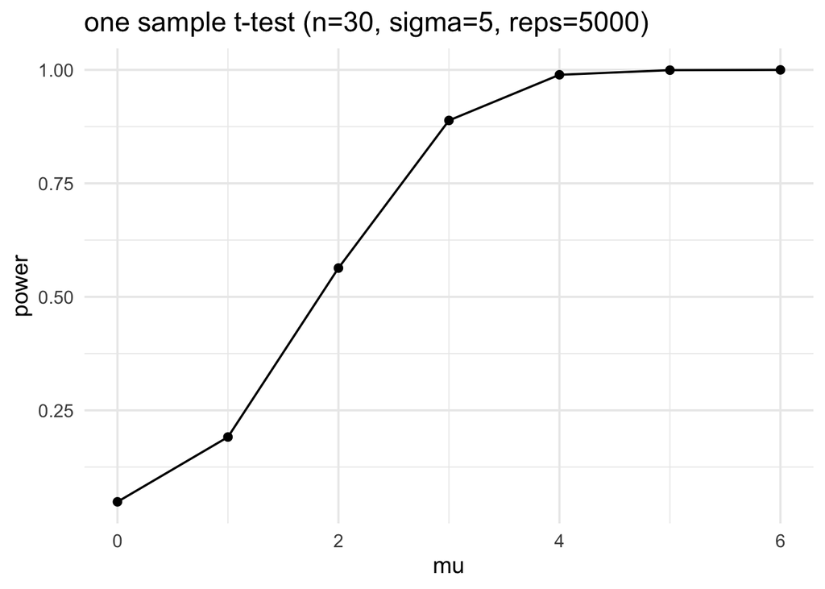

```r
p1 <- ggplot(power_by_mu, aes(x = mu, y = power)) +
  geom_line() +
  geom_point() +
  labs(title = "one sample t-test (n=30, sigma=5, reps=5000)",
x = "mu", y = "power") +
  theme_minimal(base_size = 14)

p1
```

p1 shows a strong positive association between the effect size (the true value of $\mu$) and power. - When the true $\mu$ is 0 (meaning the null hypothesis is true), the power is approximately 5%. This is the Type I error rate ($\alpha$), which is exactly what we set our significance level to. We correctly rejected the (true) null hypothesis about 5% of the time. - As the true $\mu$ increases, moving further away from the null value of 0, the power (the probability of correctly rejecting the false null) increases rapidly. - By the time the true $\mu$ reaches 4, the test has nearly 100% power, meaning it almost always detects the effect.

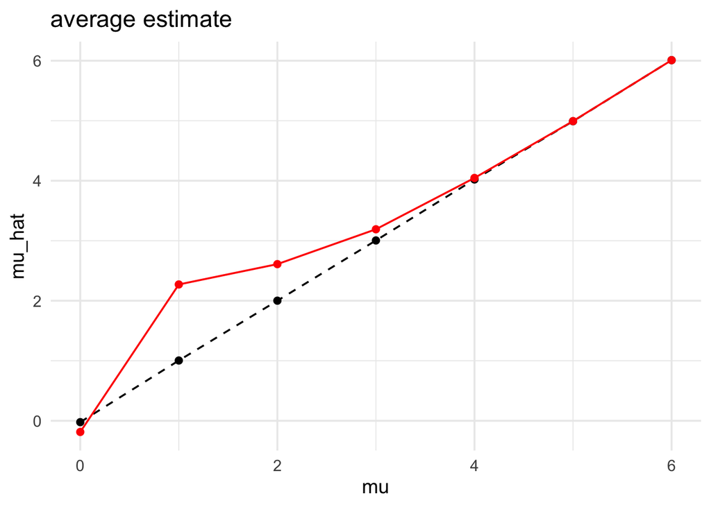

```r
p2 <- ggplot(power_by_mu, aes(x = mu)) +
  geom_line(aes(y = mean_est), linetype = "dashed") +
  geom_point(aes(y = mean_est)) +
  geom_line(aes(y = mean_est_reject), color = "red") +
  geom_point(aes(y = mean_est_reject), color = "red") +
  labs(title = "average estimate", x = "mu", y = "mu_hat") +
  theme_minimal(base_size = 14)

p2
```

Is the sample average of $\hat{\mu}$ across tests for which the null is rejected approximately equal to the true value of $\mu$? Why or why not?

## Problem 3

1.Load key packages.

```r
library(tidyverse)
library(broom)
library(purrr)
```

2.Describe the data.

```r
homicide <- read_csv("data/homicide-data.csv")
glimpse(homicide)
```

```
## Rows: 52,179
## Columns: 12
## $ uid           <chr> "Alb-000001", "Alb-000002", "Alb-000003", "Alb-000004", …
## $ reported_date <dbl> 20100504, 20100216, 20100601, 20100101, 20100102, 201001…
## $ victim_last   <chr> "GARCIA", "MONTOYA", "SATTERFIELD", "MENDIOLA", "MULA", …
## $ victim_first  <chr> "JUAN", "CAMERON", "VIVIANA", "CARLOS", "VIVIAN", "GERAL…
## $ victim_race   <chr> "Hispanic", "Hispanic", "White", "Hispanic", "White", "W…
## $ victim_age    <chr> "78", "17", "15", "32", "72", "91", "52", "52", "56", "4…
## $ victim_sex    <chr> "Male", "Male", "Female", "Male", "Female", "Female", "M…
## $ city          <chr> "Albuquerque", "Albuquerque", "Albuquerque", "Albuquerqu…
## $ state         <chr> "NM", "NM", "NM", "NM", "NM", "NM", "NM", "NM", "NM", "N…
## $ lat           <dbl> 35.09579, 35.05681, 35.08609, 35.07849, 35.13036, 35.151…
## $ lon           <dbl> -106.5386, -106.7153, -106.6956, -106.5561, -106.5810, -…
## $ disposition   <chr> "Closed without arrest", "Closed by arrest", "Closed wit…
```

```r
summary(homicide)
```

```
##      uid            reported_date       victim_last        victim_first
##  Length:52179       Min.   : 20070101   Length:52179       Length:52179
##  Class :character   1st Qu.: 20100318   Class :character   Class :character
##  Mode  :character   Median : 20121216   Mode  :character   Mode  :character
##                     Mean   : 20130899
##                     3rd Qu.: 20150911
##                     Max.   :201511105
##
##  victim_race         victim_age         victim_sex            city
##  Length:52179       Length:52179       Length:52179       Length:52179
##  Class :character   Class :character   Class :character   Class :character
##  Mode  :character   Mode  :character   Mode  :character   Mode  :character
##
##
##
##
##     state                lat             lon          disposition
##  Length:52179       Min.   :25.73   Min.   :-122.51   Length:52179
##  Class :character   1st Qu.:33.77   1st Qu.: -96.00   Class :character
##  Mode  :character   Median :38.52   Median : -87.71   Mode  :character
##                     Mean   :37.03   Mean   : -91.47
##                     3rd Qu.:40.03   3rd Qu.: -81.76
##                     Max.   :45.05   Max.   : -71.01
##                     NA's   :60      NA's   :60
```

The raw dataset contains individual homicide records from 50 major U.S. cities. Each row represents a single homicide case, including information such as the victim’s demographics, incident date, location, and case disposition. The disposition variable is particularly important because it indicates whether a homicide was solved, unsolved, or closed without an arrest. Since the dataset stores city and state in separate fields, we create a combined city_state variable to facilitate grouping and summary analyses at the city level.

3.Create city_state and summarize homicides per city.

```r
homicide_city <- homicide %>%
  mutate(city_state = paste(city, state, sep = ", "),
  unsolved = disposition %in% c("Closed without arrest", "Open/No arrest")) %>%
  group_by(city_state) %>%
  summarise(
    total = n(),
    unsolved = sum(unsolved)
  ) %>%
  arrange(desc(unsolved))

homicide_city
```

```
## # A tibble: 51 × 3
##    city_state       total unsolved
##    <chr>            <int>    <int>
##  1 Chicago, IL       5535     4073
##  2 Baltimore, MD     2827     1825
##  3 Houston, TX       2942     1493
##  4 Detroit, MI       2519     1482
##  5 Philadelphia, PA  3037     1360
##  6 Los Angeles, CA   2257     1106
##  7 New Orleans, LA   1434      930
##  8 St. Louis, MO     1677      905
##  9 Dallas, TX        1567      754
## 10 Jacksonville, FL  1168      597
## # ℹ 41 more rows
```

After creating the city_state variable, we summarize each city by computing the total number of homicides and the number of unsolved homicides. Here, unsolved cases are defined as those with dispositions “Closed without arrest” or “Open/No arrest.” This provides a clear overview of the burden of unsolved homicides across U.S. cities and forms the basis for estimating city-specific unsolved proportions.

4.Baltimore, MD – run prop.test() and extract proportion + CI

```r
baltimore <- homicide_city %>%
  filter(city_state == "Baltimore, MD")

baltimore_test <- prop.test(
  x = baltimore$unsolved,
  n = baltimore$total
)

baltimore_tidy <- tidy(baltimore_test)

baltimore_tidy %>%
  select(estimate, conf.low, conf.high)
```

```
## # A tibble: 1 × 3
##   estimate conf.low conf.high
##      <dbl>    <dbl>     <dbl>
## 1    0.646    0.628     0.663
```

For Baltimore, MD, we use prop.test() to estimate the proportion of homicides that remain unsolved. The test output, once tidied using broom::tidy(), provides the estimated proportion along with its 95% confidence interval. This gives a statistically grounded estimate of Baltimore’s unsolved rate, taking into account sampling variability.

5.Run prop.test() for all cities.

```r
city_results <- homicide_city %>%
  mutate(
    test = map2(unsolved, total, ~ prop.test(.x, .y)),
    tidy = map(test, tidy)
  ) %>%
  unnest(tidy) %>%
  select(city_state, total, unsolved, estimate, conf.low, conf.high)
city_results
```

```
## # A tibble: 51 × 6
##    city_state       total unsolved estimate conf.low conf.high
##    <chr>            <int>    <int>    <dbl>    <dbl>     <dbl>
##  1 Chicago, IL       5535     4073    0.736    0.724     0.747
##  2 Baltimore, MD     2827     1825    0.646    0.628     0.663
##  3 Houston, TX       2942     1493    0.507    0.489     0.526
##  4 Detroit, MI       2519     1482    0.588    0.569     0.608
##  5 Philadelphia, PA  3037     1360    0.448    0.430     0.466
##  6 Los Angeles, CA   2257     1106    0.490    0.469     0.511
##  7 New Orleans, LA   1434      930    0.649    0.623     0.673
##  8 St. Louis, MO     1677      905    0.540    0.515     0.564
##  9 Dallas, TX        1567      754    0.481    0.456     0.506
## 10 Jacksonville, FL  1168      597    0.511    0.482     0.540
## # ℹ 41 more rows
```

We repeat the proportion test for every city in the dataset using a tidy workflow that relies on purrr::map and list columns. For each city, we extract the estimated proportion of unsolved homicides and its confidence interval. The resulting tidy dataframe allows us to compare cities systematically and supports clear visualization with confidence intervals.

6.Plot estimates + CIs for each city.

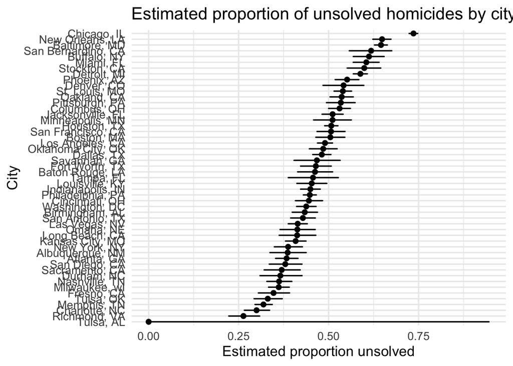

```r
city_results_plot <- city_results %>%
  arrange(estimate) %>%
  mutate(city_state = factor(city_state, levels = city_state))

p3 <- ggplot(city_results_plot, aes(x = city_state, y = estimate)) +
  geom_point() +
  geom_errorbar(aes(ymin = conf.low, ymax = conf.high), width = 0.2) +
  coord_flip() +
  labs(
    title = "Estimated proportion of unsolved homicides by city",
    x = "City",
    y = "Estimated proportion unsolved"
  ) +
  theme_minimal(base_size = 14)

p3
```

The plot displays each city’s estimated proportion of unsolved homicides, along with its corresponding confidence interval. Cities are ordered from lowest to highest unsolved proportion, allowing easy comparison across locations. Wide confidence intervals typically correspond to cities with fewer total homicides, whereas narrower intervals indicate more data and therefore more precise estimates. This visualization highlights substantial variation across cities in the proportion of unsolved homicide cases.